# Multiple regression with R

Author

Sepehr Akbari

Published

December 6, 2024

The goal of this set is to model the length of the bills of penguins in the `modeldata::penguins` set.

```r
library(tidyverse)
library(modeldata)
```

## Problem 1

Remove all observations that do not include information about the sex of the penguin. Save your result as `penguins_sm` and use it for all questions going forward.

```r
penguins_sm <- penguins %>%
  filter(!is.na(sex))
```

## Problem 2

Create an attractive scatterplot showing bill length on the y-axis (it’s the response variable) and flipper length on the x-axis. Color the points according to sex and add regression lines for the two groups.

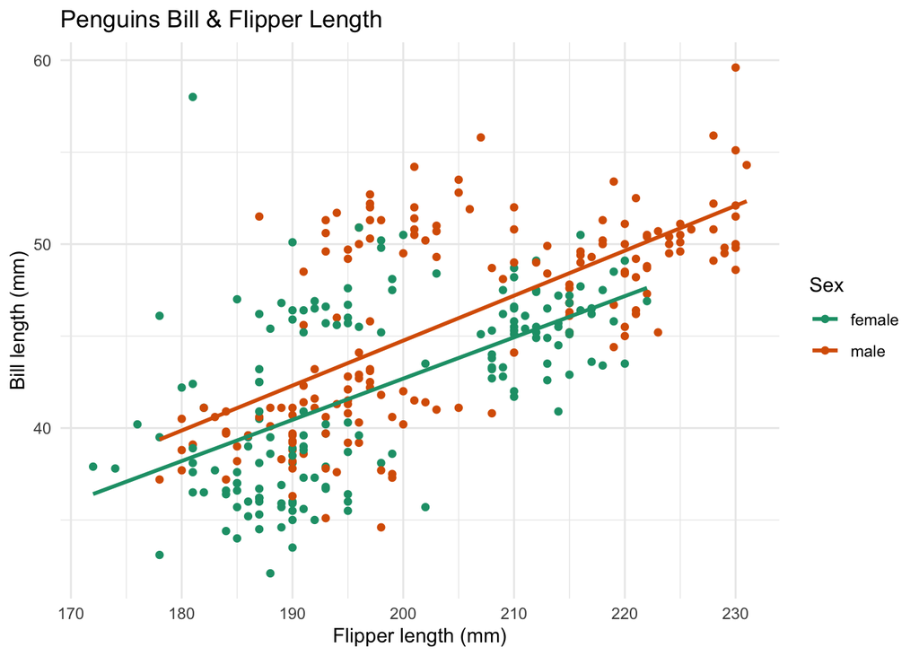

```r
ggplot(
  penguins_sm,
  aes(x = flipper_length_mm,
      y = bill_length_mm,
      color = sex)
) +
  geom_point() +
  geom_smooth(method = "lm",
              se = FALSE) +
  labs(
    x = "Flipper length (mm)",
    y = "Bill length (mm)",
    title = "Penguins Bill & Flipper Length",
    color = "Sex"
  ) +
  scale_color_brewer(palette = "Dark2") +
  theme_minimal()
```

## Problem 3

Build a linear model for bill length as explained by flipper length. What is the equation of the model? What is the adjusted $R^2$ value?

```r
modelBill_flipper <- lm(bill_length_mm ~ flipper_length_mm,
                         data = penguins_sm)
summary(modelBill_flipper)
```

```
Call:
lm(formula = bill_length_mm ~ flipper_length_mm, data = penguins_sm)

Residuals:
    Min      1Q  Median      3Q     Max
-8.6367 -2.6981 -0.5788  2.0663 19.0953

Coefficients:
                  Estimate Std. Error t value Pr(>|t|)
(Intercept)       -7.21856    3.27175  -2.206    0.028 *
flipper_length_mm  0.25482    0.01624  15.691   <2e-16 ***
---
Signif. codes:  0 '***' 0.001 '**' 0.01 '*' 0.05 '.' 0.1 ' ' 1

Residual standard error: 4.148 on 331 degrees of freedom
Multiple R-squared:  0.4265,    Adjusted R-squared:  0.4248
F-statistic: 246.2 on 1 and 331 DF,  p-value: < 2.2e-16
```

The equation of the model is:

$$\text{bill length} = 0.25 (\text{flipper length}) -7.22$$

The adjusted $R^2$ value is **0.4248**, meaning approximately 42.48% of the variability in bill length is explained by flipper length. The predictor, flipper length, is highly significant (p < 2e-16), indicating a strong relationship with bill length.

## Problem 4

Build a linear model for bill length as explained by flipper length and body mass. What is the equation of the model? What is the adjusted $R^2$ value?

```r
modelBill_flipper_mass <- lm(bill_length_mm ~ flipper_length_mm + body_mass_g,
                              data = penguins_sm)
summary(modelBill_flipper_mass)
```

```
Call:
lm(formula = bill_length_mm ~ flipper_length_mm + body_mass_g,
    data = penguins_sm)

Residuals:
    Min      1Q  Median      3Q     Max
-8.8251 -2.6432 -0.7281  2.0229 18.8227

Coefficients:
                    Estimate Std. Error t value Pr(>|t|)
(Intercept)       -3.9812079  4.7215540  -0.843    0.400
flipper_length_mm  0.2271747  0.0333014   6.822 4.31e-11 ***
body_mass_g        0.0005513  0.0005797   0.951    0.342
---
Signif. codes:  0 '***' 0.001 '**' 0.01 '*' 0.05 '.' 0.1 ' ' 1

Residual standard error: 4.148 on 330 degrees of freedom
Multiple R-squared:  0.4281,    Adjusted R-squared:  0.4246
F-statistic: 123.5 on 2 and 330 DF,  p-value: < 2.2e-16
```

The equation of the model is:

$$\text{bill length} = 0.23 (\text{flipper length}) + 0.00055 (\text{body mass}) - 3.98$$

The adjusted $R^2$ value is **0.4246**, meaning approximately 42.46% of the variability in bill length is explained by flipper length and body mass together. However, the inclusion of body mass does not improve the model significantly (p = 0.342). This suggests that flipper length remains the primary predictor of bill length in this model.

## Problem 5

Build a linear model for bill length as explained by body mass and sex. What is the equation of the model? What is the adjusted $R^2$ value?

```r
modelBill_mass_sex <- lm(bill_length_mm ~ body_mass_g + sex,
                         data = penguins_sm)
summary(modelBill_mass_sex)
```

```
Call:
lm(formula = bill_length_mm ~ body_mass_g + sex, data = penguins_sm)

Residuals:
     Min       1Q   Median       3Q      Max
-10.7196  -3.2501  -0.7724   2.5415  16.4992

Coefficients:
             Estimate Std. Error t value Pr(>|t|)
(Intercept) 2.791e+01  1.323e+00  21.095   <2e-16 ***
body_mass_g 3.674e-03  3.309e-04  11.102   <2e-16 ***
sexmale     1.247e+00  5.321e-01   2.344   0.0197 *
---
Signif. codes:  0 '***' 0.001 '**' 0.01 '*' 0.05 '.' 0.1 ' ' 1

Residual standard error: 4.395 on 330 degrees of freedom
Multiple R-squared:  0.3581,    Adjusted R-squared:  0.3542
F-statistic: 92.06 on 2 and 330 DF,  p-value: < 2.2e-16
```

The equation of the model is:

$$\text{bill length} = 0.0037 (\text{body mass}) + 1.25 (\text{sex}) + 27.91$$
$\text{[Where Male = 1, Female = 0]}$

The adjusted $R^2$ value is **0.3542**, meaning approximately 35.42% of the variability in bill length is explained by body mass and sex together. Both predictors are significant:

- Body mass (p < 2e-16) has a small but meaningful positive contribution.
- Sex (p = 0.0197) indicates that males have, on average, a bill length approximately 1.25 mm longer than females, holding body mass constant.

## Problem 6

Build a linear model for bill length as explained by flipper length, body mass, and sex. What is the equation of the model? What is the adjusted $R^2$ value?

```r
modelBill_flipper_mass_sex <- lm(bill_length_mm ~ flipper_length_mm + body_mass_g + sex,
              data = penguins_sm)
summary(modelBill_flipper_mass_sex)
```

```
Call:
lm(formula = bill_length_mm ~ flipper_length_mm + body_mass_g +
    sex, data = penguins_sm)

Residuals:
    Min      1Q  Median      3Q     Max
-9.6131 -2.8005 -0.6307  2.1699 20.1682

Coefficients:
                    Estimate Std. Error t value Pr(>|t|)
(Intercept)       -8.0754117  4.6732129  -1.728   0.0849 .
flipper_length_mm  0.2672650  0.0335203   7.973 2.57e-14 ***
body_mass_g       -0.0006670  0.0006232  -1.070   0.2853
sexmale            2.3047154  0.5055670   4.559 7.27e-06 ***
---
Signif. codes:  0 '***' 0.001 '**' 0.01 '*' 0.05 '.' 0.1 ' ' 1

Residual standard error: 4.029 on 329 degrees of freedom
Multiple R-squared:  0.4621,    Adjusted R-squared:  0.4572
F-statistic:  94.2 on 3 and 329 DF,  p-value: < 2.2e-16
```

The equation of the model is:

$$\text{bill length} = 0.27 (\text{flipper length}) - 0.00067 (\text{body mass}) + 2.3 (\text{sex}) - 8.08$$

$\text{[Where Male = 1, Female = 0]}$